# Course 5 week 2 peer assignment

## Course 5 week 2

### Loading and preprocessing the data

This assumes the file **activity.csv** to be present in the working directory.  
Furthermore the interval is made a factor and the date a real date.

```r
activities <- read.csv("activity.csv",stringsAsFactors = FALSE)
activities$date <- as.Date(activities$date)
activities$interval <- as.factor(activities$interval)
```

### What is mean total number of steps taken per day?

A histogram of the mean total number of steps per day is shown.  
Next the mean and median steps per day are shown.

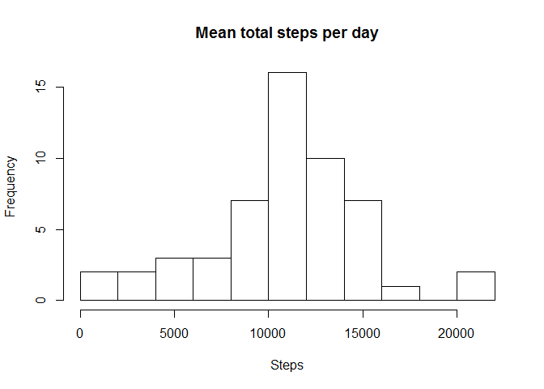

```r
steps.per.day <- aggregate(activities$steps,by=list(activities$date),sum)
names(steps.per.day) <- c("Date","Total")
hist(steps.per.day$Total,main="Mean total steps per day",
                      ,breaks=10,xlab="Steps",ylab="Frequency")
```

```r
steps.per.day.mean <- mean(steps.per.day$Total,na.rm=TRUE)
steps.per.day.median <- median(steps.per.day$Total,na.rm=TRUE)
```

Mean steps per day: 10766.19  
Median steps per day: 10765

### What is the average daily activity pattern?

For each of the 288 timesof day of 5 minutes the average number of steps is calculated.  
Finally the time of day with the most activity is reported

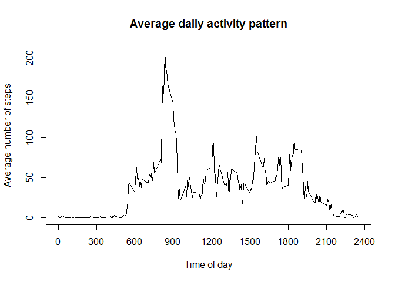

```r
steps.per.interval <- aggregate(activities$steps,
                                by=list(activities$interval),
                                mean,na.rm=TRUE)
names(steps.per.interval) <- c("Interval","Mean")
with(steps.per.interval,plot(as.numeric(as.character(Interval)),Mean,type="l",
                             xaxt="n",
                             main="Average daily activity pattern",
                             xlab="Time of day",ylab="Average number of steps"))
axis(side=1,at=seq(0,2400,by=300))
```

```r
print(paste("time of day with highest average number of steps: ",
            steps.per.interval[which.max(steps.per.interval$Mean),1]))
```

```
## [1] "time of day with highest average number of steps:  835"
```

### Imputing missing values

How many observations are missing?  
Impute the missing values by taking the average (mean) for that interval of the day.

```r
print(paste("Number of missing values: ",sum(is.na(activities$steps))))
```

```
## [1] "Number of missing values:  2304"
```

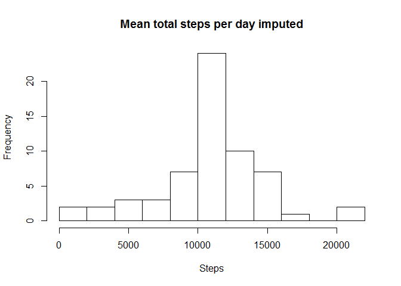

```r
activities.imputed <- activities
activities.imputed[is.na(activities.imputed$steps),]$steps <-
  steps.per.interval[activities.imputed
    [is.na(activities.imputed$steps),]$interval,]$Mean
steps.per.day.imputed <-
  aggregate(activities.imputed$steps,by=list(activities.imputed$date),sum)
names(steps.per.day.imputed) <- c("Date","Total")
hist(steps.per.day.imputed$Total,main="Mean total steps per day imputed",
                      ,breaks=10,xlab="Steps",ylab="Frequency")
```

```r
steps.per.day.imputed.mean <- mean(steps.per.day.imputed$Total,na.rm=TRUE)
steps.per.day.imputed.median <- median(steps.per.day.imputed$Total,na.rm=TRUE)
```

### Are there differences in activity patterns between weekdays and weekends?

```r
library(lattice)
```

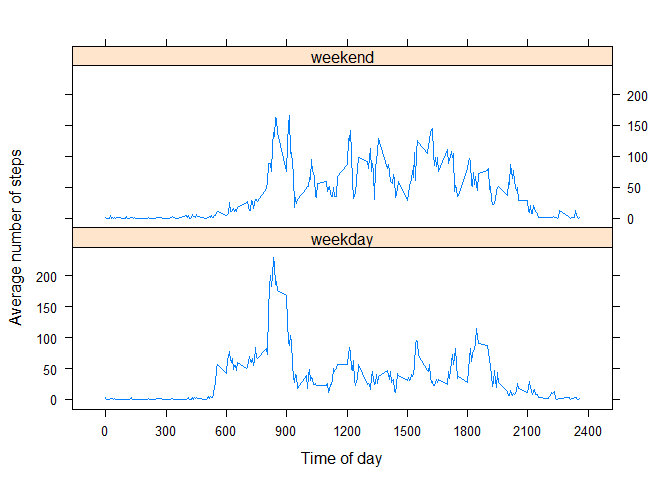

```r
activities.imputed$day <- weekdays(activities.imputed$date)
activities.imputed$day[activities.imputed$day
                         %in% c("zaterdag","zondag")] <- "weekend"
activities.imputed$day[activities.imputed$day != "weekend"] <- "weekday"
steps.per.interval.day <-
  aggregate(activities.imputed$steps,
            by=list(activities.imputed$interval,activities.imputed$day),
            mean)
names(steps.per.interval.day) = c("interval","day","mean")
xyplot(mean ~ as.numeric(as.character(interval))|day,
       data=steps.per.interval.day, type="l",
       layout=c(1,2),xlab="Time of day",ylab="Average number of steps",
       scales=list(x=list(at=seq(0,2400,by=300),labels=seq(0,2400,by=300))))
```

There are differences between weekend and workdays:  
Activity in the weekend is more spread over the day where at workdays it is concentrated before 9.